# 2023_Deep_7_catch_exploration

# Gindai

Catch through time

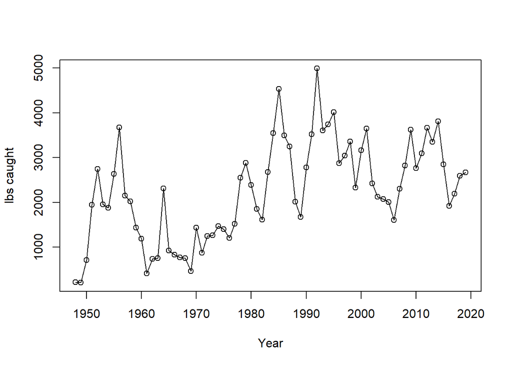

Number of catch records by year

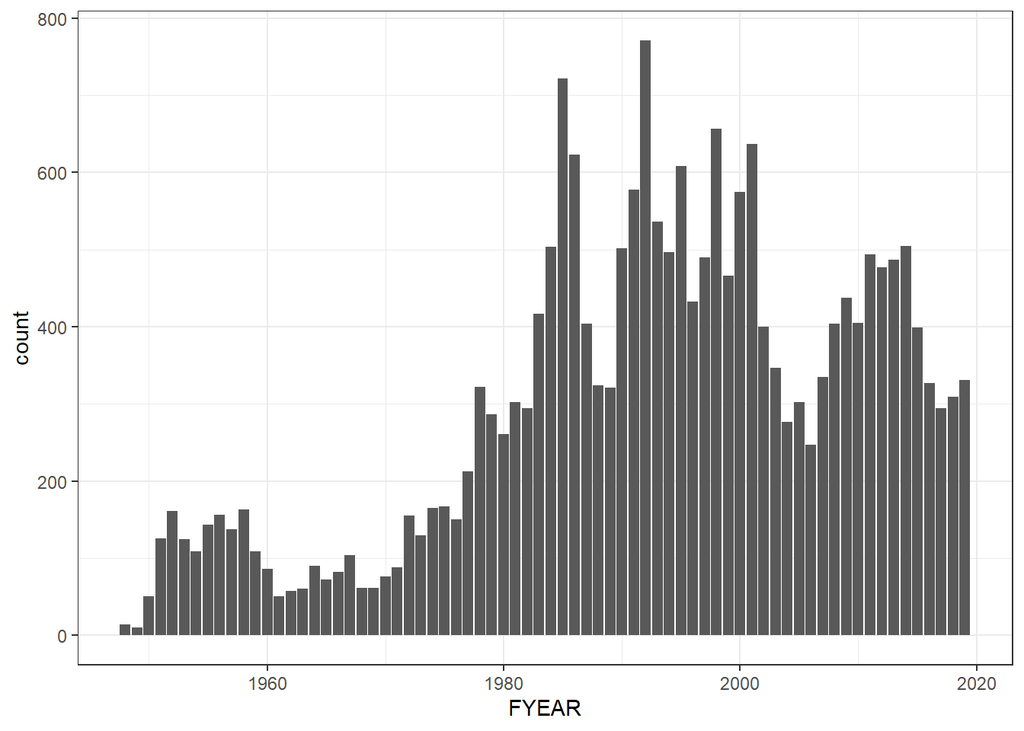

```
##    Min. 1st Qu.  Median    Mean 3rd Qu.    Max.
##    1948    1984    1994    1993    2006    2019
```

Catch by calendar month (monthly mean among calendar years)

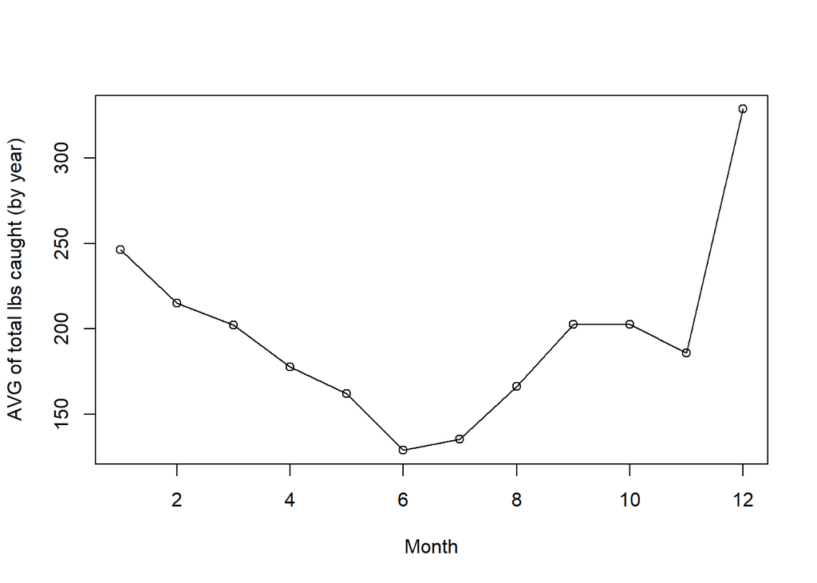

Number of catch records by region (years pooled)

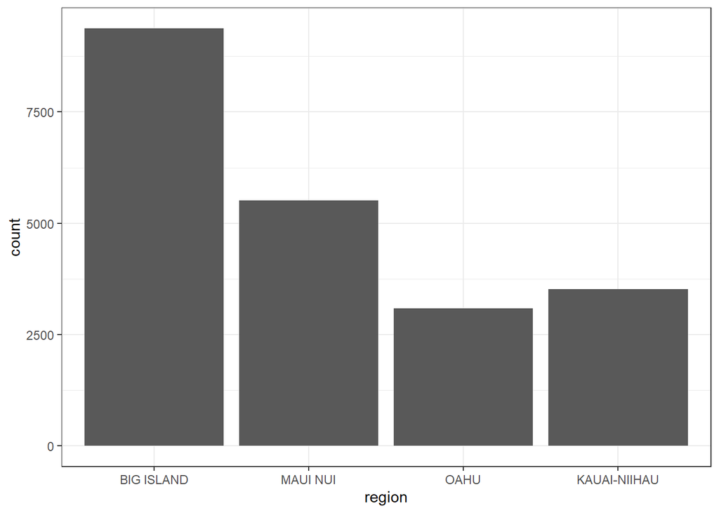

```
##   BIG ISLAND     MAUI NUI         OAHU KAUAI-NIIHAU
##         9374         5507         3085         3520
```

Proportion of gindai catch (in lbs) by island region through time

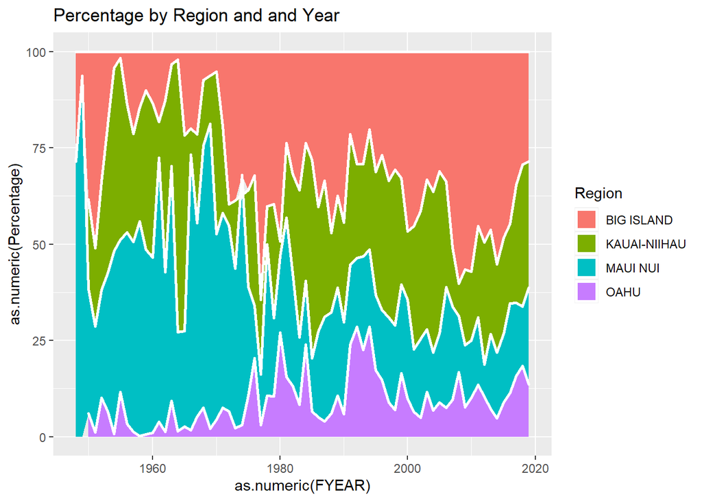

Look at catch by HDAR reporting area

Proportion of records in top 10 and 20 areas, respectively (years pooled).

```
## [1] 0.4047205
```

```
## [1] 0.6257385
```

Top 10 areas ("Group.1")

```
##     Group.1        x
## 53      331 15371.99
## 107     528  7462.50
## 10      120  7087.60
## 91      500  6082.20
## 102     523  5426.50
## 12      122  5352.70
## 16      126  5148.20
## 52      328  4729.30
## 11      121  4642.40
## 106     527  4523.00
```

Maps of catch by HDAR reporting area (total and decade)

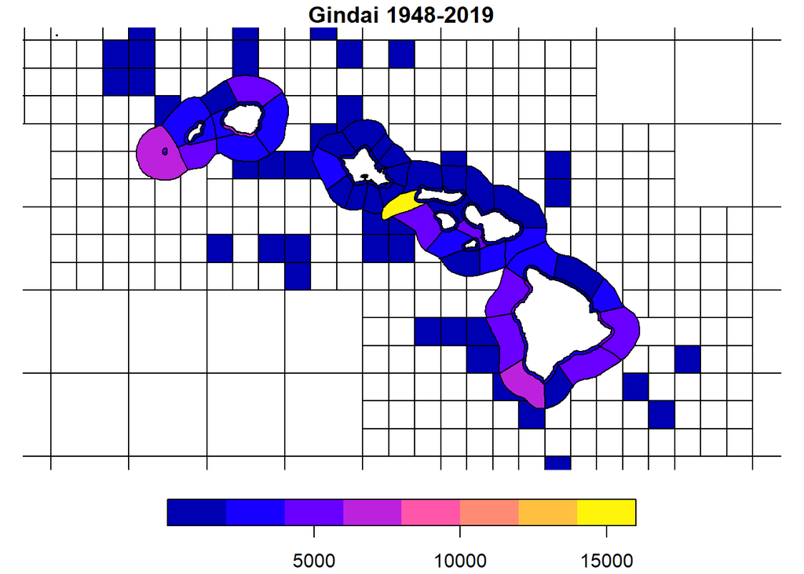

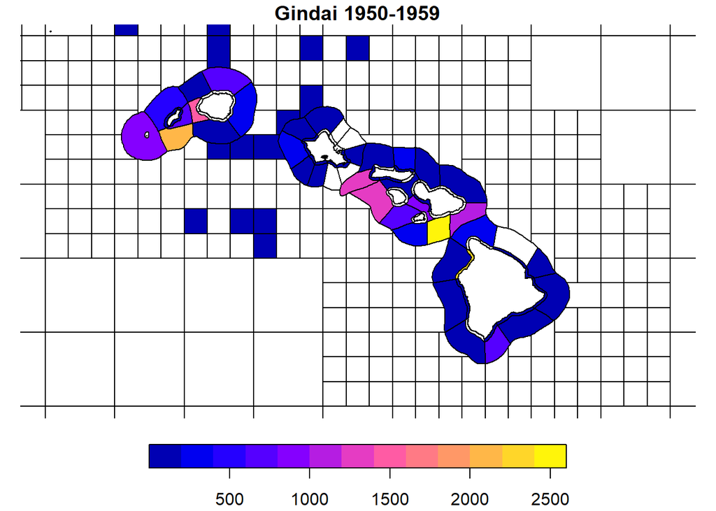

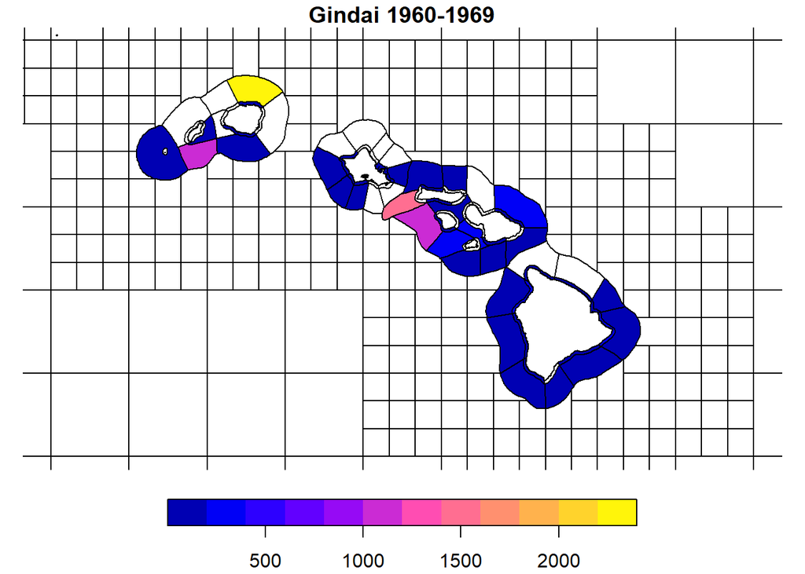

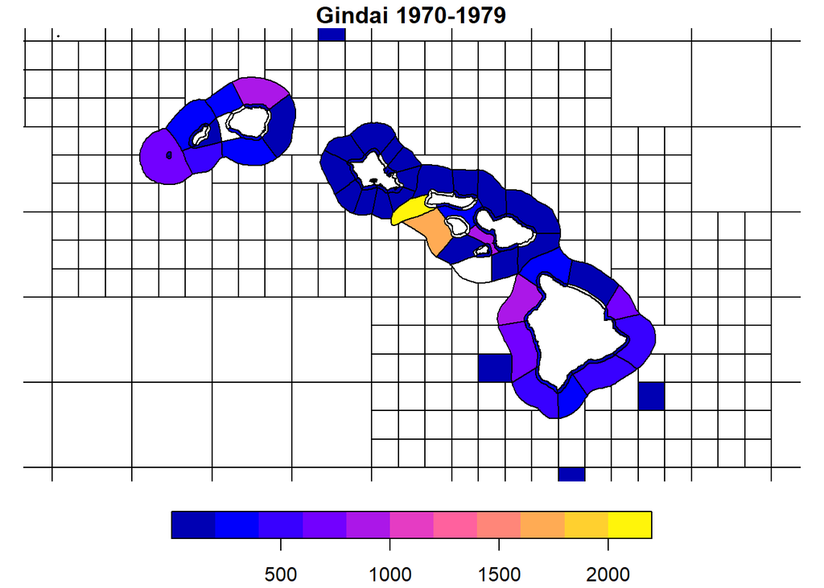

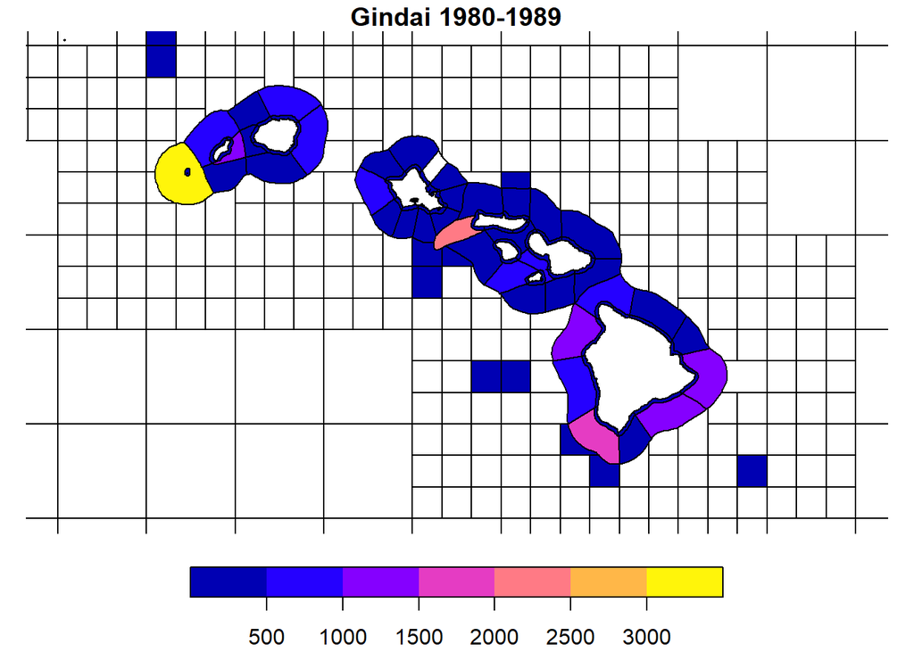

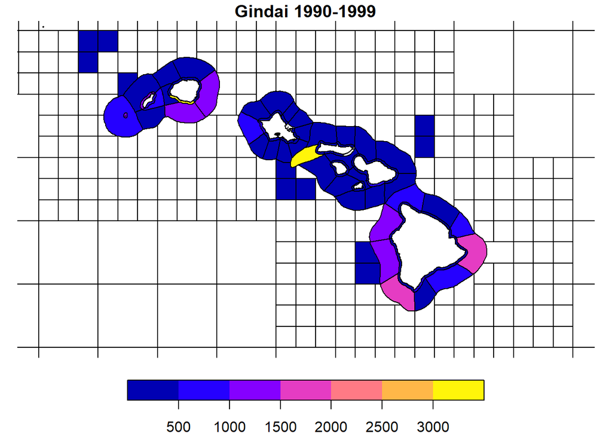

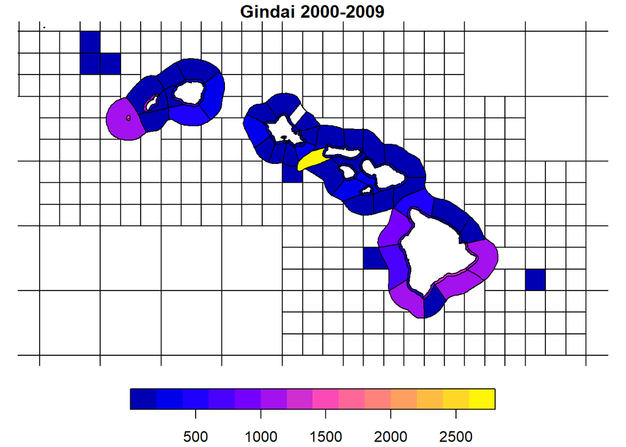

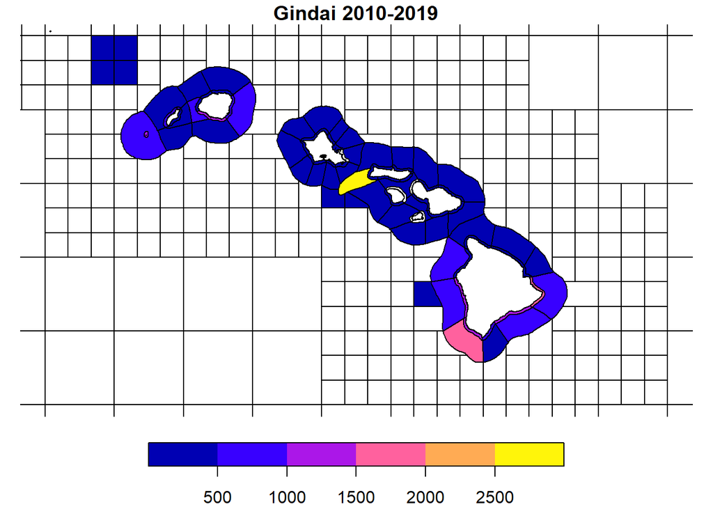

Catch by gear

```
## [1] 0.03477234
```

```
## [1] 0.03607
```

Catch by gear through time

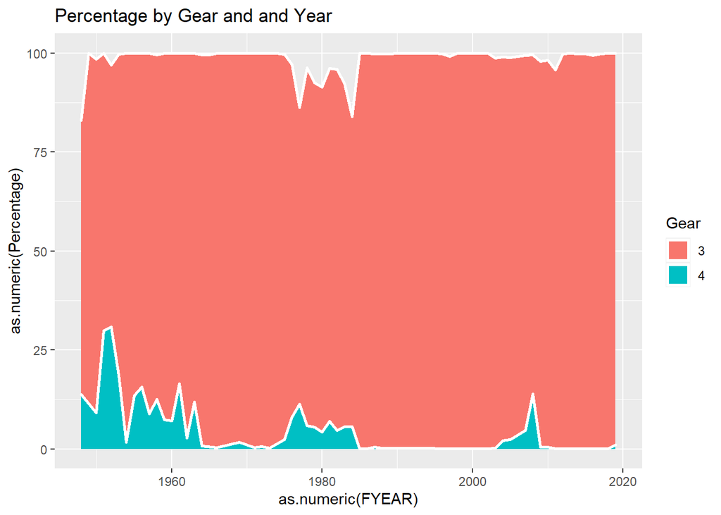